# 03-BoxPlot Day-4

## BOX Plots

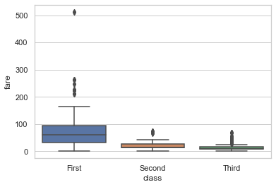

```python
#import libraries
import seaborn
#canvas (Baloon Board)
seaborn.set(style='whitegrid')
#load dataset
boat = sns.load_dataset("titanic")
boat
#Draw a line plot
seaborn.boxplot(x="class", y="fare", data=boat)
```

## Tips

```python
#import libraries
import seaborn
#canvas (Baloon Board)
seaborn.set(style='whitegrid')
tip = seaborn.load_dataset('tips')
tip
```

|  | total_bill | tip | sex | smoker | day | time | size |
| --- | --- | --- | --- | --- | --- | --- | --- |
| 0 | 16.99 | 1.01 | Female | No | Sun | Dinner | 2 |
| 1 | 10.34 | 1.66 | Male | No | Sun | Dinner | 3 |
| 2 | 21.01 | 3.50 | Male | No | Sun | Dinner | 3 |
| 3 | 23.68 | 3.31 | Male | No | Sun | Dinner | 2 |
| 4 | 24.59 | 3.61 | Female | No | Sun | Dinner | 4 |
| ... | ... | ... | ... | ... | ... | ... | ... |
| 239 | 29.03 | 5.92 | Male | No | Sat | Dinner | 3 |
| 240 | 27.18 | 2.00 | Female | Yes | Sat | Dinner | 2 |
| 241 | 22.67 | 2.00 | Male | Yes | Sat | Dinner | 2 |
| 242 | 17.82 | 1.75 | Male | No | Sat | Dinner | 2 |
| 243 | 18.78 | 3.00 | Female | No | Thur | Dinner | 2 |

244 rows × 7 columns

## Simple Disk grapgh

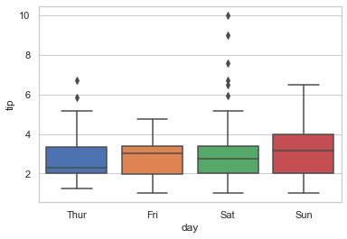

```python
#import libraries
import seaborn
#canvas (Baloon Board)
seaborn.set(style='whitegrid')
tip = seaborn.load_dataset('tips')
tip
seaborn.boxplot(x='day', y='tip', data=tip, saturation=1.1)
```

## Pandas

```python
#import libraries
import seaborn as sns
import pandas as pf
import numpy as np
#canvas (Baloon Board)

tip = seaborn.load_dataset('tips')
tip.describe() #descripe all element in data
```

|  | total_bill | tip | size |
| --- | --- | --- | --- |
| count | 244.000000 | 244.000000 | 244.000000 |
| mean | 19.785943 | 2.998279 | 2.569672 |
| std | 8.902412 | 1.383638 | 0.951100 |
| min | 3.070000 | 1.000000 | 1.000000 |
| 25% | 13.347500 | 2.000000 | 2.000000 |
| 50% | 17.795000 | 2.900000 | 2.000000 |
| 75% | 24.127500 | 3.562500 | 3.000000 |
| max | 50.810000 | 10.000000 | 6.000000 |

## One Things Boxplots

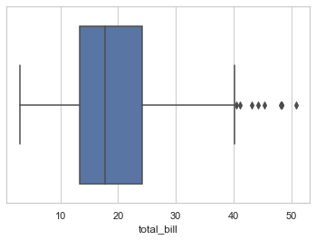

```python
#import libraries
import seaborn
#canvas (Baloon Board)
seaborn.set(style='whitegrid')
#Loading DataSets
tip = seaborn.load_dataset('tips')
seaborn.boxplot(x= tip['total_bill'])
```

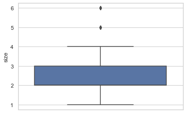

```python
#import libraries
import seaborn
#canvas (Baloon Board)
seaborn.set(style='whitegrid')
#Loading DataSets
tip = seaborn.load_dataset('tips')
seaborn.boxplot(y= tip['size'])
```

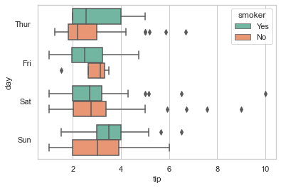

```python
#import libraries
import seaborn
#canvas (Baloon Board)
seaborn.set(style='whitegrid')
#Loading DataSets
tip = seaborn.load_dataset('tips')
seaborn.boxplot(x='tip', y='day', hue='smoker', data=tip, palette ="Set2", dodge=True,  )
```

## Color Pickers

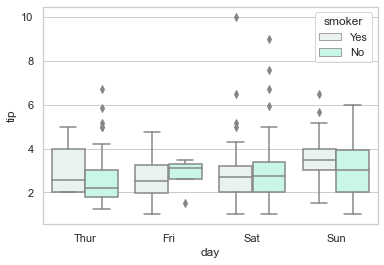

```python
#import libraries
import seaborn
#canvas (Baloon Board)
seaborn.set(style='whitegrid')
#Loading DataSets
tip = seaborn.load_dataset('tips')
seaborn.boxplot(x='day', y='tip', hue="smoker",data=tip, color= "#c0ffee" )
```

## Customizing Plots

```python
import seaborn as sns
import pandas as pd
import numpy as np

boat = sns.load_dataset("titanic")
boat.head()
```

|  | survived | pclass | sex | age | sibsp | parch | fare | embarked | class | who | adult_male | deck | embark_town | alive | alone |
| --- | --- | --- | --- | --- | --- | --- | --- | --- | --- | --- | --- | --- | --- | --- | --- |
| 0 | 0 | 3 | male | 22.0 | 1 | 0 | 7.2500 | S | Third | man | True | NaN | Southampton | no | False |
| 1 | 1 | 1 | female | 38.0 | 1 | 0 | 71.2833 | C | First | woman | False | C | Cherbourg | yes | False |
| 2 | 1 | 3 | female | 26.0 | 0 | 0 | 7.9250 | S | Third | woman | False | NaN | Southampton | yes | True |
| 3 | 1 | 1 | female | 35.0 | 1 | 0 | 53.1000 | S | First | woman | False | C | Southampton | yes | False |
| 4 | 0 | 3 | male | 35.0 | 0 | 0 | 8.0500 | S | Third | man | True | NaN | Southampton | no | True |

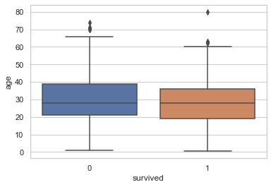

```python
sns.boxplot(x="survived", y="age", data=boat)
```

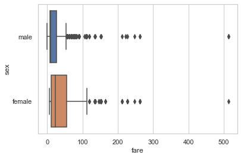

```python
sns.boxplot(x="fare", y="sex", data=boat)
```

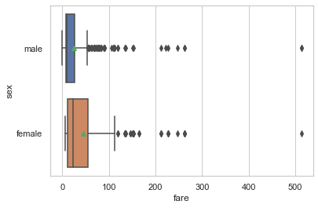

```python
sns.boxplot(x="fare", y="sex", showmeans=True, data=boat)
```

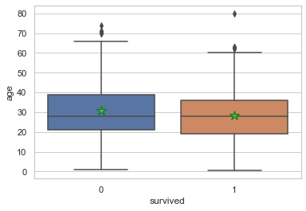

```python
sns.boxplot(x="survived", y="age", showmeans=True, meanprops={"marker":"*", "markersize": "12", "markeredgecolor": "green"}, data=boat)
```

## FaceGrid and FaceWrap

Seaborn is a Python data visualization library based on matplotlib. It provides a high-level interface for drawing attractive and informative statistical graphics. Seaborn helps resolve the two major problems faced by Matplotlib; the problems are ?

Default Matplotlib parameters Working with data frames As Seaborn compliments and extends Matplotlib, the learning curve is quite gradual. If you know Matplotlib, you are already half way through Seaborn.

seaborn.FacetGrid() : FacetGrid class helps in visualizing distribution of one variable as well as the relationship between multiple variables separately within subsets of your dataset using multiple panels. A FacetGrid can be drawn with up to three dimensions ? row, col, and hue. The first two have obvious correspondence with the resulting array of axes; think of the hue variable as a third dimension along a depth axis, where different levels are plotted with different colors. FacetGrid object takes a dataframe as input and the names of the variables that will form the row, column, or hue dimensions of the grid. The variables should be categorical and the data at each level of the variable will be used for a facet along that axis.

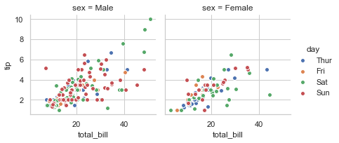

```python
# importing packages
import seaborn
import matplotlib.pyplot as plt

# loading of a dataframe from seaborn
df = seaborn.load_dataset('tips')

############# Main Section         #############
# Form a facetgrid using columns with a hue
graph = seaborn.FacetGrid(df, col ="sex",  hue ="day")
# map the above form facetgrid with some attributes
graph.map(plt.scatter, "total_bill", "tip", edgecolor ="w").add_legend()
# show the object
plt.show()

# This code is contributed by Deepanshu Rustagi.
```

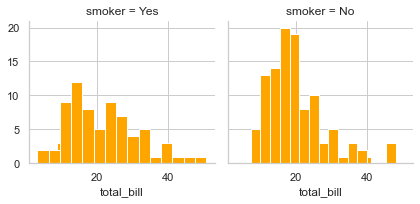

```python
# importing packages
import seaborn
import matplotlib.pyplot as plt

# loading of a dataframe from seaborn
df = seaborn.load_dataset('tips')

############# Main Section         #############
# Form a facetgrid using columns with a hue
graph = seaborn.FacetGrid(df, col ="smoker",  hue ="time")
# map the above form facetgrid with some attributes
graph.map(plt.hist, 'total_bill', bins = 15, color ='orange')
# show the object
plt.show()

# This code is contributed by Deepanshu Rustagi.
```